# STOCK PRICE PREDICTION PROJECT

```python
import numpy as np
import pandas as pd
import os
import matplotlib.pyplot as plt
import warnings
warnings.filterwarnings('ignore')
from matplotlib.pylab import rcParams
rcParams['figure.figsize'] = 15, 6
```

```python
display (os.getcwd())
```

```
'C:\\Users\\HP'
```

```python
os.chdir ('D:\\BTech\\MACHINE LEARNING\\PRJ Stock Price Prediction\\')
```

```python
display (os.getcwd())
```

```
'D:\\BTech\\MACHINE LEARNING\\PRJ Stock Price Prediction'
```

```python
df =pd.read_csv("prices.csv", header=0)
display (df)
```

|  | date | symbol | open | close | low | high | volume |
| --- | --- | --- | --- | --- | --- | --- | --- |
| 0 | 2016-01-05 00:00:00 | WLTW | 123.430000 | 125.839996 | 122.309998 | 126.250000 | 2163600.0 |
| 1 | 2016-01-06 00:00:00 | WLTW | 125.239998 | 119.980003 | 119.940002 | 125.540001 | 2386400.0 |
| 2 | 2016-01-07 00:00:00 | WLTW | 116.379997 | 114.949997 | 114.930000 | 119.739998 | 2489500.0 |
| 3 | 2016-01-08 00:00:00 | WLTW | 115.480003 | 116.620003 | 113.500000 | 117.440002 | 2006300.0 |
| 4 | 2016-01-11 00:00:00 | WLTW | 117.010002 | 114.970001 | 114.089996 | 117.330002 | 1408600.0 |
| ... | ... | ... | ... | ... | ... | ... | ... |
| 851259 | 2016-12-30 | ZBH | 103.309998 | 103.199997 | 102.849998 | 103.930000 | 973800.0 |
| 851260 | 2016-12-30 | ZION | 43.070000 | 43.040001 | 42.689999 | 43.310001 | 1938100.0 |
| 851261 | 2016-12-30 | ZTS | 53.639999 | 53.529999 | 53.270000 | 53.740002 | 1701200.0 |
| 851262 | 2016-12-30 00:00:00 | AIV | 44.730000 | 45.450001 | 44.410000 | 45.590000 | 1380900.0 |
| 851263 | 2016-12-30 00:00:00 | FTV | 54.200001 | 53.630001 | 53.389999 | 54.480000 | 705100.0 |

851264 rows × 7 columns

```python
print(df.shape)
print(df.columns)
```

```
(851264, 7)
Index(['date', 'symbol', 'open', 'close', 'low', 'high', 'volume'], dtype='object')
```

```python
#Value count (Number of records by company)
df.symbol.value_counts()
```

```
symbol
KSU     1762
NOC     1762
ORCL    1762
OMC     1762
OKE     1762
        ...
KHC      378
HPE      304
CSRA     284
WLTW     251
FTV      126
Name: count, Length: 501, dtype: int64
```

```python
#Unique Values
df.symbol.unique()

#Number of Unique Values
display(df.symbol.unique().shape)
```

```
(501,)
```

```python
#First 20 Unique values
df.symbol.unique()[0:20]

#Number of Records
print(len(df.symbol.values))

#Display Info
df.info()
```

```
851264
<class 'pandas.core.frame.DataFrame'>
RangeIndex: 851264 entries, 0 to 851263
Data columns (total 7 columns):
 #   Column  Non-Null Count   Dtype
---  ------  --------------   -----
 0   date    851264 non-null  object
 1   symbol  851264 non-null  object
 2   open    851264 non-null  float64
 3   close   851264 non-null  float64
 4   low     851264 non-null  float64
 5   high    851264 non-null  float64
 6   volume  851264 non-null  float64
dtypes: float64(5), object(2)
memory usage: 45.5+ MB
```

```python
#Check for NULL Values
df.isnull().sum()
```

```
date      0
symbol    0
open      0
close     0
low       0
high      0
volume    0
dtype: int64
```

```python
#Get all Unique Dates
df.date.unique()
```

```
array(['2016-01-05 00:00:00', '2016-01-06 00:00:00',
       '2016-01-07 00:00:00', ..., '2016-12-28', '2016-12-29',
       '2016-12-30'], dtype=object)
```

```python
#Display Date as  Data Frame
pd.DataFrame(df.date.unique())
```

|  | 0 |
| --- | --- |
| 0 | 2016-01-05 00:00:00 |
| 1 | 2016-01-06 00:00:00 |
| 2 | 2016-01-07 00:00:00 |
| 3 | 2016-01-08 00:00:00 |
| 4 | 2016-01-11 00:00:00 |
| ... | ... |
| 3519 | 2016-12-23 |
| 3520 | 2016-12-27 |
| 3521 | 2016-12-28 |
| 3522 | 2016-12-29 |
| 3523 | 2016-12-30 |

3524 rows × 1 columns

```python
#Check for Duplicate Records
df.duplicated().sum()
```

```
0
```

```python
#Load the File
comp_info = pd.read_csv('securities.csv')
comp_info
```

|  | Ticker symbol | Security | SEC filings | GICS Sector | GICS Sub Industry | Address of Headquarters | Date first added | CIK |
| --- | --- | --- | --- | --- | --- | --- | --- | --- |
| 0 | MMM | 3M Company | reports | Industrials | Industrial Conglomerates | St. Paul, Minnesota | NaN | 66740 |
| 1 | ABT | Abbott Laboratories | reports | Health Care | Health Care Equipment | North Chicago, Illinois | 31-03-1964 | 1800 |
| 2 | ABBV | AbbVie | reports | Health Care | Pharmaceuticals | North Chicago, Illinois | 31-12-2012 | 1551152 |
| 3 | ACN | Accenture plc | reports | Information Technology | IT Consulting & Other Services | Dublin, Ireland | 06-07-2011 | 1467373 |
| 4 | ATVI | Activision Blizzard | reports | Information Technology | Home Entertainment Software | Santa Monica, California | 31-08-2015 | 718877 |
| ... | ... | ... | ... | ... | ... | ... | ... | ... |
| 500 | YHOO | Yahoo Inc. | reports | Information Technology | Internet Software & Services | Sunnyvale, California | NaN | 1011006 |
| 501 | YUM | Yum! Brands Inc | reports | Consumer Discretionary | Restaurants | Louisville, Kentucky | 06-10-1997 | 1041061 |
| 502 | ZBH | Zimmer Biomet Holdings | reports | Health Care | Health Care Equipment | Warsaw, Indiana | NaN | 1136869 |
| 503 | ZION | Zions Bancorp | reports | Financials | Regional Banks | Salt Lake City, Utah | NaN | 109380 |
| 504 | ZTS | Zoetis | reports | Health Care | Pharmaceuticals | Florham Park, New Jersey | 21-06-2013 | 1555280 |

505 rows × 8 columns

```python
#Check for Unique count
comp_info["Ticker symbol"].nunique()

#Check for info
comp_info.info()

#Check for Null Values
comp_info.isnull().sum()
```

```
<class 'pandas.core.frame.DataFrame'>
RangeIndex: 505 entries, 0 to 504
Data columns (total 8 columns):
 #   Column                   Non-Null Count  Dtype
---  ------                   --------------  -----
 0   Ticker symbol            505 non-null    object
 1   Security                 505 non-null    object
 2   SEC filings              505 non-null    object
 3   GICS Sector              505 non-null    object
 4   GICS Sub Industry        505 non-null    object
 5   Address of Headquarters  505 non-null    object
 6   Date first added         307 non-null    object
 7   CIK                      505 non-null    int64
dtypes: int64(1), object(7)
memory usage: 31.7+ KB
```

```
Ticker symbol                0
Security                     0
SEC filings                  0
GICS Sector                  0
GICS Sub Industry            0
Address of Headquarters      0
Date first added           198
CIK                          0
dtype: int64
```

```python
#Describe the Details
comp_info.describe()
```

|  | CIK |
| --- | --- |
| count | 5.050000e+02 |
| mean | 7.074490e+05 |
| std | 5.144375e+05 |
| min | 1.800000e+03 |
| 25% | 8.631200e+04 |
| 50% | 8.310010e+05 |
| 75% | 1.075531e+06 |
| max | 1.659166e+06 |

```python
#Search for 10 company details
 #(demostrating for10 companies)

comp_plot = comp_info.loc[(comp_info["Security"] == 'Yahoo Inc.') | (comp_info["Security"] == 'Xerox Corp.')
              | (comp_info["Security"] == 'Microsoft Corp.') | (comp_info["Security"] == 'Adobe Systems Inc')
              | (comp_info["Security"] == 'Facebook') | (comp_info["Security"] == 'Goldman Sachs Group')
              | (comp_info["Security"] == 'International Business Machines') | (comp_info["Security"] == 'Intel Corp.')
              | (comp_info["Security"] == 'Netflix Inc.') | (comp_info["Security"] == 'Nike'), ["Ticker symbol"] ]["Ticker symbol"]
print(comp_plot)
```

```
6      ADBE
181      FB
212      GS
240    INTC
242     IBM
306    MSFT
322    NFLX
330     NKE
496     XRX
500    YHOO
Name: Ticker symbol, dtype: object
```

```python
#For Loop to display 10 Company names
for i in comp_plot:
    print (i)
```

```
ADBE
FB
GS
INTC
IBM
MSFT
NFLX
NKE
XRX
YHOO
```

```python
#Creating a function to plot Graphs for selected companies  opening stock and closing stock against time
def plotter(code):
    # Function used to create graphs for 10 companies
    global closing_stock ,opening_stock
    #creating plot of all 10 company for opening and closing stock  total 20 graphs
    # Below statement create 2X2 empty chart
    f, axs = plt.subplots(2,2,figsize=(15,8))
    # total 20 graphs
    # creating plot opening prize of particular company
    plt.subplot(212)
    #taking name of the company as code, get all records related to one company
    company = df[df['symbol']==code]
    #taking the values of one company and taking its open column values to 1D array
    company = company.open.values.astype('float32')
    #reshaping the open stock value from 1D  to 2D .
    company = company.reshape(-1, 1)
    # putting the value of company in opening_stock
    opening_stock = company
    # plotting the data with green graph between "Time" and "prices vs time"

    plt.grid(True)                           # enalbling the grid in graph
    plt.xlabel('Time')                       # setting X axis as time
    # setting Y axis as company name + open stock prices
    plt.ylabel(code + " open stock prices")
    plt.title('prices Vs Time')              # setting title
    plt.plot(company , 'g')                  # calling the graph with green graph line

    # creating plot closing prize of particular company
    plt.subplot(211)
    #taking name of the company as code
    company_close = df[df['symbol']==code]
    #taking the values of one company and taking its close column values
    company_close = company_close.close.values.astype('float32')
    #reshaping the open column value in 1D and calling it closing_stock
   # -1 for unknown dimension
    company_close = company_close.reshape(-1, 1)
    # putting company_close value in closing_stock
    closing_stock = company_close
    # plotting the data graph between "Time" and "prices vs time"
    plt.xlabel('Time')                            # setting x axis as time
    plt.ylabel(code + " close stock prices")      # setting y axis as company name + open stock prices
    plt.title('prices Vs Time')                   # setting title as price vs time
    plt.grid(True)                                # enabling the grid in graph
    plt.plot(company_close , 'b')                 #creating the data graph in blue graph line
    plt.show()                                    # calling the graph
```

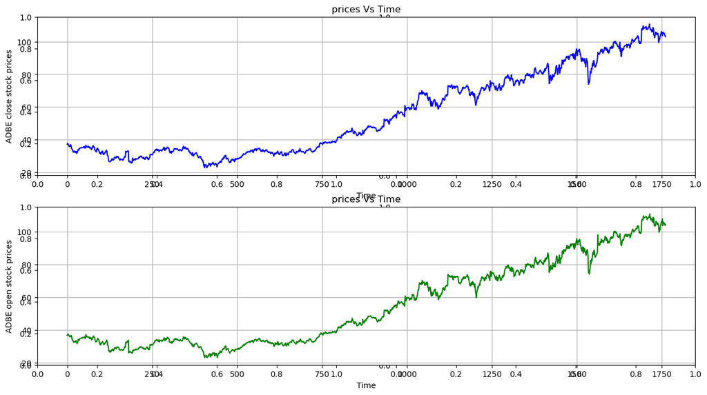

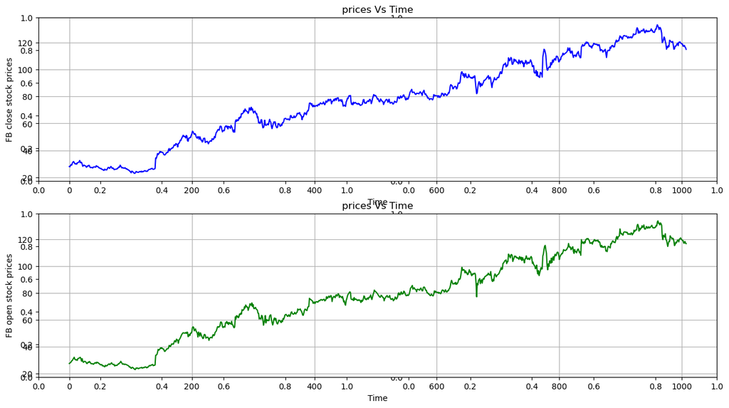

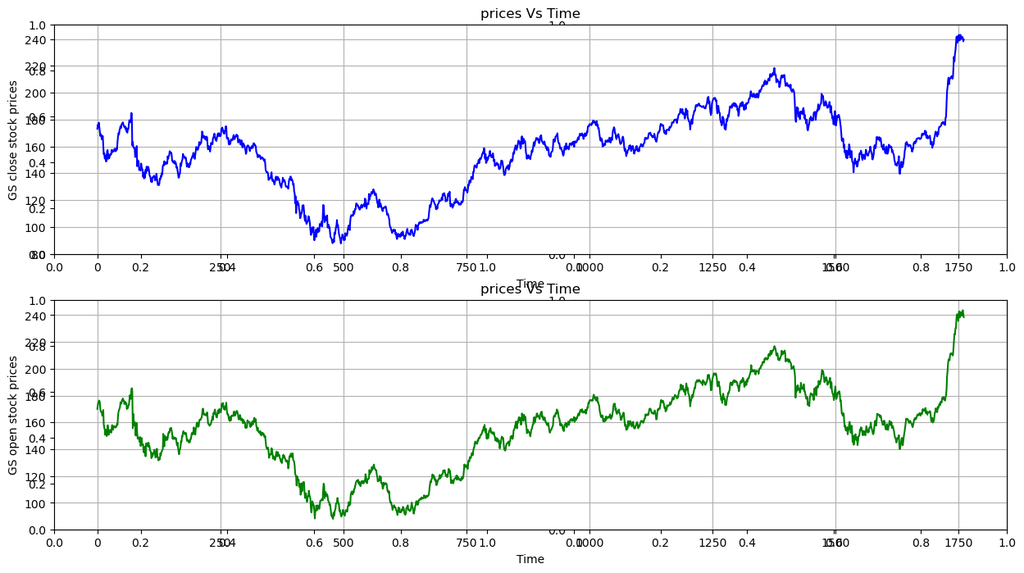

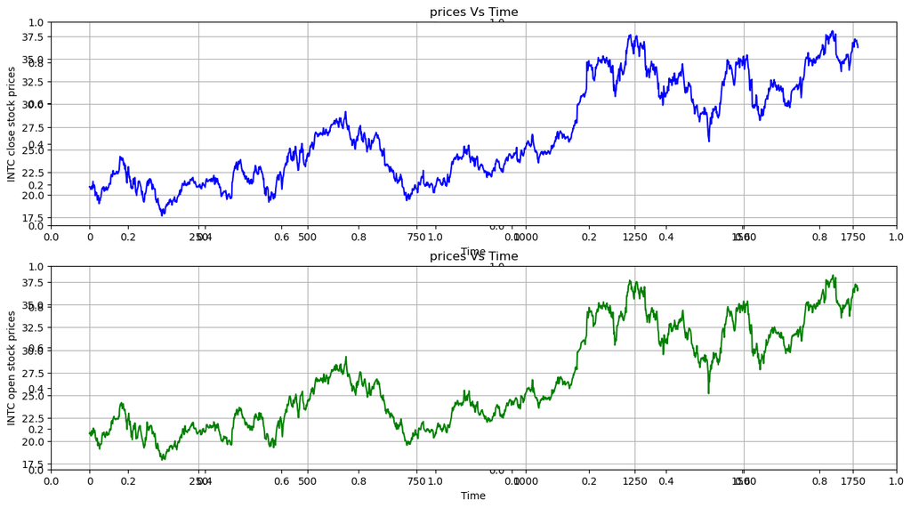

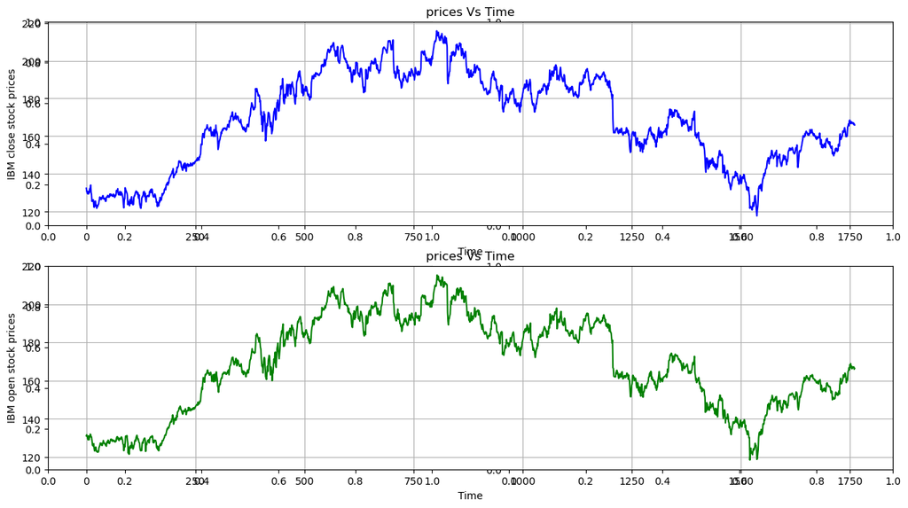

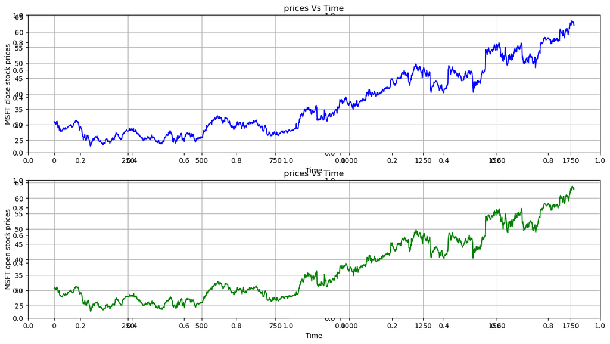

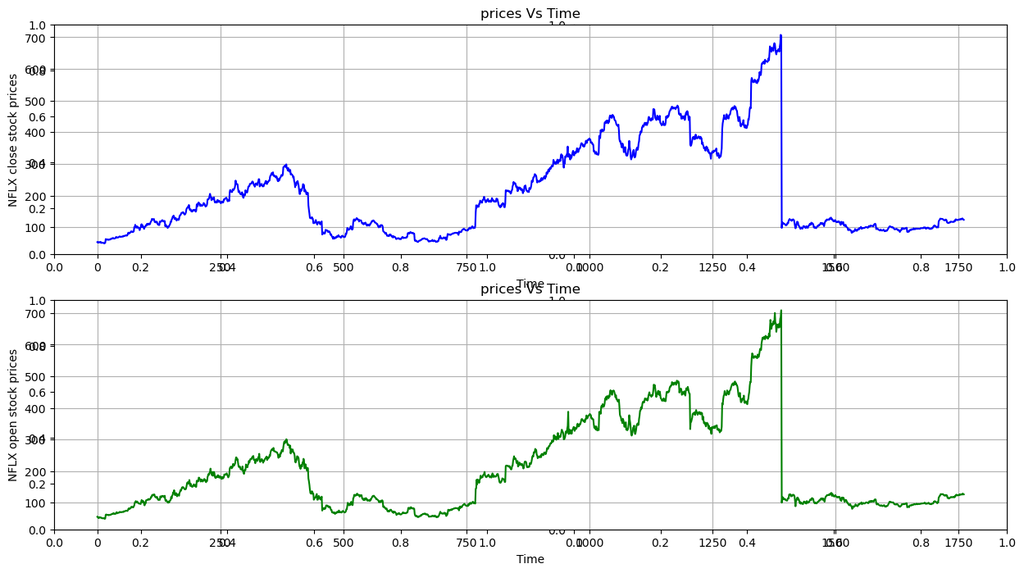

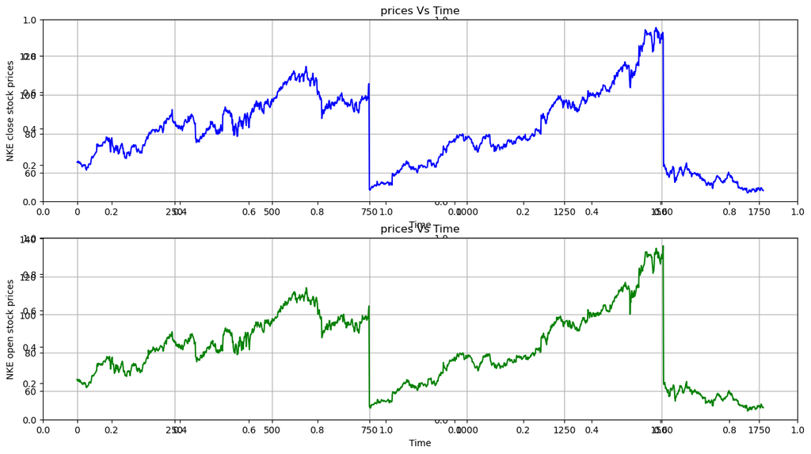

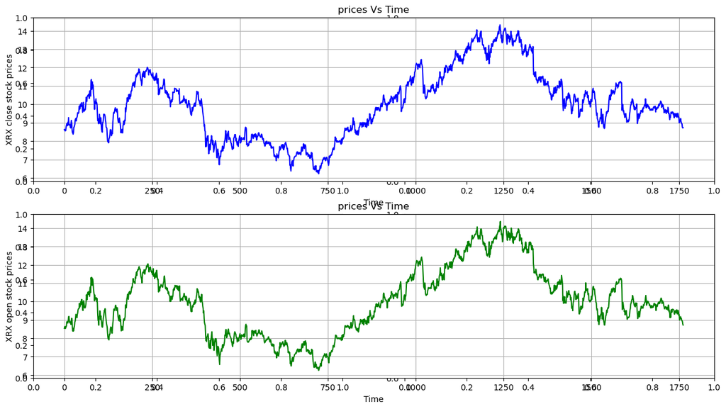

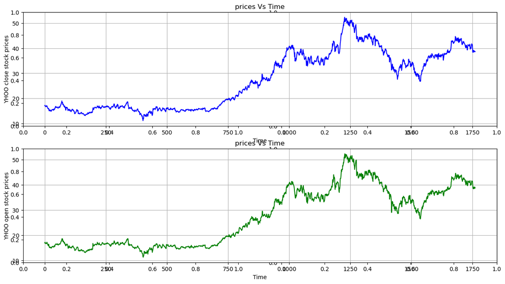

```python
for i in comp_plot:     #calling graphs
    plotter(i)
```

### Plot Summary

1.Adobe report As we can see, that close and open started around 38 points and shows an increasing growth with time. The open and close graph closes at a very high position (around 105) compared to the start.

2.Facebook report As the graph shows, open and close started around 30 points. And from there, it shows a bit downfall time 150. But then it shows a massive uprise and ends at the120 points for both open and close.

3.Goldman Sachs As we see in graphs of open and close stocks, we see that Goldman has taken many up and downs almost the whole journey. It starts from high points than others around 175 points and faced major downfall but at last, it reached higher to 240 points.

4.Intel corp. As we can see, that close and open stocks started around 21 points and exerience downfalls till time 750 then it rises and ends at around 36 points.

5.International Business Machines As we see in the graph, the close and open stocks started around 135 points and then attain its maximum price at around time 760 and graphs closes at around 170 points.

6.Microsoft As the graphs explain open and close stock for Microsoft started from 30 points. And from there they show total elevation to 65 points. It is a great option for investment.

7.Netflix Inc. As wee see in graph,the open and close stock stated at around 50 points and performs ok then suddenly experience a drop at time around 1450 and ends at around 120points.

9.Xerox As the graphs suggest for Xerox, it started from very low points of 9 and from there it struggled to progress. There was a major fall after some time and in the end, the stock prices are still nearly the same.

10.Yahoo As we see in the graphs, Yahoo prices remained the same for some time. But then they show effective progress. And at the end, they go to around 40 points.

```python
#Extract closing stock of company, here ADBE
stocks1= np.array (df[df.symbol.isin (['ADBE'])].close)

#Convert stock to 2D array
stocks1 = stocks1.reshape(len(stocks1) , 1)
print (stocks1.shape)
print(stocks1)
```

```
(1762, 1)
[[ 37.09    ]
 [ 37.700001]
 [ 37.619999]
 ...
 [103.769997]
 [103.68    ]
 [102.949997]]
```

```python
#Extract closing stock   of one company, here YHOO
stocks= np.array (df[df.symbol.isin (['YHOO'])].close)
print(stocks)

#Display Shape
display (stocks.shape)

#Convert stock to 2D array
stocks = stocks.reshape(len(stocks) , 1)
print (stocks.shape)
print(stocks)
```

```
[17.1      17.23     17.17     ... 38.73     38.639999 38.669998]
```

```
(1762,)
```

```
(1762, 1)
[[17.1     ]
 [17.23    ]
 [17.17    ]
 ...
 [38.73    ]
 [38.639999]
 [38.669998]]
```

```python
from sklearn.preprocessing import MinMaxScaler
```

# feature scaling

```python
scaler = MinMaxScaler(feature_range=(0, 1))
stocks = scaler.fit_transform(stocks)
display (stocks)
```

```
array([[0.14559109],
       [0.14874031],
       [0.14728683],
       ...,
       [0.66957366],
       [0.6673934 ],
       [0.66812012]])
```

```python
#Train Test Split (80 % Training and 20 % Test Data)
#Total Number of Records
print (stocks.shape)
```

```
(1762, 1)
```

```python
# 80 % Training record count
train = int(len(stocks) * 0.80)
print ("training data=",train)

# 20 % record count    (Total – 80%)
test = len(stocks) - train
print ("test data=" ,test)
```

```
training data= 1409
test data= 353
```

```python
#Training Data
#divinding the values of stocks data to train from 0 to 1409 i.e 80% data
train = stocks[0:train]
display (train.shape)
print(train)
```

```
(1409, 1)
```

```
[[0.14559109]
 [0.14874031]
 [0.14728683]
 ...
 [0.63372095]
 [0.61458332]
 [0.61967051]]
```

```python
#Test Data
#divinding the values of stocks data to test from train ending to stock data ending i.e rest 20% data
test = stocks[len(train) : ]
display(test.shape)
display (test)
```

```
(353, 1)
```

```
array([[0.63129851],
       [0.60416666],
       [0.56686053],
       [0.6017442 ],
       [0.60925394],
       [0.60586237],
       [0.59593022],
       [0.58381782],
       [0.55741276],
       [0.52906978],
       [0.48982557],
       [0.50024226],
       [0.51913761],
       [0.54748061],
       [0.53415697],
       [0.51235471],
       [0.49685079],
       [0.500969  ],
       [0.51962213],
       [0.49636629],
       [0.47989342],
       [0.4949128 ],
       [0.48594962],
       [0.49273257],
       [0.46584303],
       [0.48328492],
       [0.49200583],
       [0.48062017],
       [0.47601745],
       [0.48643412],
       [0.46778102],
       [0.45179265],
       [0.44210272],
       [0.43701549],
       [0.39995156],
       [0.41593993],
       [0.43168606],
       [0.43168606],
       [0.47529068],
       [0.47868218],
```

[output cut: 298 more lines]

```
       [0.74297478],
       [0.73183139],
       [0.73594965],
       [0.72238374],
       [0.66182172],
       [0.66666671],
       [0.66206392],
       [0.67999033],
       [0.67974813],
       [0.66400195],
       [0.66787792],
       [0.67417632],
       [0.66957366],
       [0.6673934 ],
       [0.66812012]])
```

```python
#creating function to create trainX,testX and target(trainY, testY)
def process_data(data , n_features):
    dataX, dataY = [], []           # creating data for dataset and dividing inta X,Y
    for i in range(len(data)-n_features):
           # taking i range from total size- 3
        a = data[i:(i+n_features), 0]
        # Here a is value of data from i to i+ n_features, ie two values and put it in dataX
        dataX.append(a) #putting a in dataX
        #here dataY takes the value of data of i + n_features
        dataY.append(data[i + n_features, 0])
        # putting i+ n_features in  dataY
    return np.array(dataX), np.array(dataY)
# returning dataX and dataY in array
```

```python
#Call the function to prepare training data
n_features=2
trainX, trainY = process_data(train, n_features)
print(trainX.shape , trainY.shape)
```

```
(1407, 2) (1407,)
```

```python
#Call the function to prepare test data -
n_features = 2
testX, testY = process_data(test, n_features)
print (testX.shape , testY.shape)
```

```
(351, 2) (351,)
```

```python
#Call the function to prepare full  data -
n_features = 2
stocksX, stocksY = process_data(stocks, n_features)
print (stocksX.shape , stocksY.shape)
```

```
(1760, 2) (1760,)
```

```python
#Display the First 10 Records from Train X
display (trainX[:10])

#Display the First 10 Records from TrainY
display (trainY[:10])
```

```
array([[0.14559109, 0.14874031],
       [0.14874031, 0.14728683],
       [0.14728683, 0.13590119],
       [0.13590119, 0.13590119],
       [0.13590119, 0.13687016],
       [0.13687016, 0.13541667],
       [0.13541667, 0.14074613],
       [0.14074613, 0.14607561],
       [0.14607561, 0.13880814],
       [0.13880814, 0.13711241]])
```

```
array([0.14728683, 0.13590119, 0.13590119, 0.13687016, 0.13541667,
       0.14074613, 0.14607561, 0.13880814, 0.13711241, 0.1281492 ])
```

```python
# reshaping trainX and testX to use in deep learning model
trainX = trainX.reshape(trainX.shape[0] , 1 ,trainX.shape[1])
display (trainX.shape)
#Reshape to 3D array test X
testX = testX.reshape(testX.shape[0] , 1 ,testX.shape[1])
display (testX.shape)
#Reshape to 3D array  full data set
stocksX= stocksX.reshape(stocksX.shape[0] , 1 ,stocksX.shape[1])
display (stocksX.shape)
```

```
(1407, 1, 2)
```

```
(351, 1, 2)
```

```
(1760, 1, 2)
```

```python
import math
# for setting layers one by one neural layer in model
from keras.models import Sequential
# types of layers
from keras.layers import Dense , BatchNormalization , Dropout , Activation
# types of RNN
from keras.layers import LSTM , GRU
#It puts the data in between given range to set data before putting layer
from sklearn.preprocessing import MinMaxScaler
# In this method the errors in column is squared and then mean is found
from sklearn.metrics import mean_squared_error
# Optimizers used
from tensorflow.keras.optimizers import Adam , SGD , RMSprop
```

```python
#Checkpointing the model when required and using other call-backs.
filepath="stock_weights1.hdf5"
from keras.callbacks import ReduceLROnPlateau , ModelCheckpoint
# ReduceLROnPlateau- This reduce the learning rate when the matrix stop improving or  too close to reduce overfitting
lr_reduce = ReduceLROnPlateau(monitor='val_loss', factor=0.1, min_delta =0.0001, patience=1, verbose=1)
#This check point will stop processing, if the model is not improving.
checkpoint = ModelCheckpoint(filepath, monitor='val_loss', verbose=1, save_best_only=True, mode='max')
```

```python
# creating model for training data using sequential to give series wise output between layers
model = Sequential()
# GRU or Gated Recurrent Unit used for matrix manipulation within Recurrent layer
#This is the input Layer
model.add(GRU(256 , input_shape = (1 , n_features) , return_sequences=True))
#dropout is used to remove overfitting data on each layer of neural network
model.add(Dropout(0.4))
#Long Short Term Memory is a type of RNN specially used for time series problems
model.add(LSTM(256))
#dropout is used to remove overfitting data on each layer of neural network
model.add(Dropout(0.4))
#Dense layer are fully connected neural networks
model.add(Dense(64 ,  activation = 'relu'))
#This is the output Layer, Output is only one neuron
model.add(Dense(1))
#for getting the details of our models
print(model.summary())
```

```
Model: "sequential"
_________________________________________________________________
 Layer (type)                Output Shape              Param #
=================================================================
 gru (GRU)                   (None, 1, 256)            199680

 dropout (Dropout)           (None, 1, 256)            0

 lstm (LSTM)                 (None, 256)               525312

 dropout_1 (Dropout)         (None, 256)               0

 dense (Dense)               (None, 64)                16448

 dense_1 (Dense)             (None, 1)                 65

=================================================================
Total params: 741,505
Trainable params: 741,505
Non-trainable params: 0
_________________________________________________________________
None
```

```python
# Selecting the loss measurement metrics and optimizer for our model, to find out mean square error
model.compile(loss='mean_squared_error', optimizer=Adam(lr = 0.0005) , metrics = ['mean_squared_error'])
```

```python
history = model.fit(trainX, trainY, epochs=100 , batch_size = 128 ,
          callbacks = [checkpoint , lr_reduce] , validation_data = (testX,testY))
```

```
Epoch 1: val_loss improved from -inf to 0.15344, saving model to stock_weights1.hdf5
Epoch 2: val_loss did not improve from 0.15344
Epoch 3: val_loss did not improve from 0.15344

Epoch 3: ReduceLROnPlateau reducing learning rate to 5.0000002374872565e-05.
Epoch 4: val_loss did not improve from 0.15344

Epoch 4: ReduceLROnPlateau reducing learning rate to 5.000000237487257e-06.
Epoch 5: val_loss did not improve from 0.15344

Epoch 5: ReduceLROnPlateau reducing learning rate to 5.000000328436726e-07.
Epoch 6: val_loss did not improve from 0.15344

Epoch 6: ReduceLROnPlateau reducing learning rate to 5.000000555810402e-08.
Epoch 7: val_loss did not improve from 0.15344

Epoch 7: ReduceLROnPlateau reducing learning rate to 5.000000413701855e-09.
Epoch 8: val_loss did not improve from 0.15344

Epoch 8: ReduceLROnPlateau reducing learning rate to 5.000000413701855e-10.
Epoch 9: val_loss did not improve from 0.15344

Epoch 9: ReduceLROnPlateau reducing learning rate to 5.000000413701855e-11.
Epoch 10: val_loss did not improve from 0.15344

Epoch 10: ReduceLROnPlateau reducing learning rate to 5.000000413701855e-12.
Epoch 11: val_loss did not improve from 0.15344

Epoch 11: ReduceLROnPlateau reducing learning rate to 5.000000413701855e-13.
Epoch 12: val_loss did not improve from 0.15344

Epoch 12: ReduceLROnPlateau reducing learning rate to 5.0000005221220725e-14.
Epoch 13: val_loss did not improve from 0.15344

Epoch 13: ReduceLROnPlateau reducing learning rate to 5.000000589884709e-15.
Epoch 14: val_loss did not improve from 0.15344

Epoch 14: ReduceLROnPlateau reducing learning rate to 5.000000759291298e-16.
Epoch 15: val_loss did not improve from 0.15344

```

[output cut: 129 more lines]

```
Epoch 86: val_loss did not improve from 0.15344
Epoch 87: val_loss did not improve from 0.15344
Epoch 88: val_loss did not improve from 0.15344
Epoch 89: val_loss did not improve from 0.15344
Epoch 90: val_loss did not improve from 0.15344
Epoch 91: val_loss did not improve from 0.15344
Epoch 92: val_loss did not improve from 0.15344
Epoch 93: val_loss did not improve from 0.15344
Epoch 94: val_loss did not improve from 0.15344
Epoch 95: val_loss did not improve from 0.15344
Epoch 96: val_loss did not improve from 0.15344
Epoch 97: val_loss did not improve from 0.15344
Epoch 98: val_loss did not improve from 0.15344
Epoch 99: val_loss did not improve from 0.15344
Epoch 100: val_loss did not improve from 0.15344
```

```python
#Predict the value for testX, display top 10 records

test_pred = model.predict(testX)
display (test_pred [:10])
```

```
array([[0.55787593],
       [0.5345133 ],
       [0.5350402 ],
       [0.54974025],
       [0.55101055],
       [0.546092  ],
       [0.5381305 ],
       [0.5240447 ],
       [0.50443876],
       [0.4801695 ]], dtype=float32)
```

```python
#Inverse Transform the data – Convert the data to Original form
test_pred = scaler.inverse_transform(test_pred)
display (test_pred [:10])
```

```
array([[34.119118],
       [33.15471 ],
       [33.17646 ],
       [33.783276],
       [33.835716],
       [33.632675],
       [33.304028],
       [32.722565],
       [31.91323 ],
       [30.911398]], dtype=float32)
```

```python
testY = testY.reshape(testY.shape[0] , 1)
#Converting reshaped list in 1D array so that it will be efficient in plotting
testY = scaler.inverse_transform(testY)
# taking testY from 1 to 10
display (testY[:10])
```

```
array([[34.490002],
       [35.93    ],
       [36.240002],
       [36.099998],
       [35.689999],
       [35.189999],
       [34.099998],
       [32.93    ],
       [31.309999],
       [31.74    ]])
```

```python
#Display the accuracy
from sklearn.metrics import r2_score
r2_score(testY,test_pred)
```

```
0.6149007902491821
```

```
Red - Predicted Stock Prices  ,  Blue - Actual Stock Prices
```

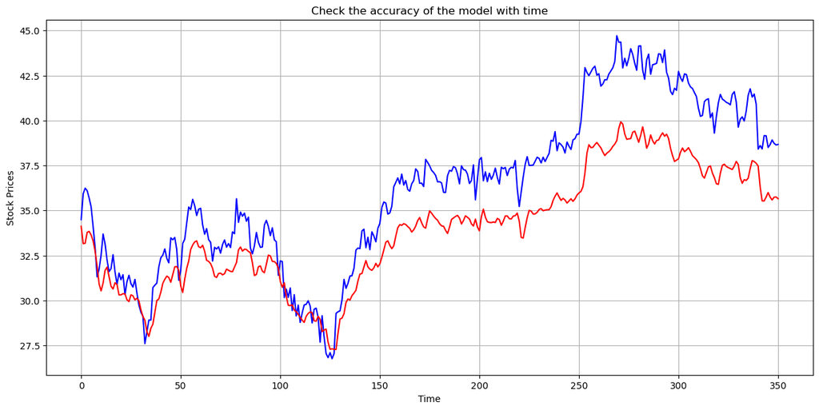

```python
# Ploting the graph of stock prices with time
print("Red - Predicted Stock Prices  ,  Blue - Actual Stock Prices")
plt.rcParams["figure.figsize"] = (15,7)
# testY is the blue line
plt.plot(testY , 'b')
# pred is the red line
plt.plot(test_pred , 'r')
# Setting x axis as time
plt.xlabel('Time')
# Setting y axis as stock prices
plt.ylabel('Stock Prices')
# setting title
plt.title('Check the accuracy of the model with time')
# enabling grids in graph
plt.grid(True)
# it call the graph with labels, titles, lines
plt.show()
```

```python
#Prediction Training Data and Check Accuracy
train_pred = model.predict(trainX)
train_pred = scaler.inverse_transform(train_pred)
trainY = trainY.reshape(trainY.shape[0] , 1)
trainY = scaler.inverse_transform(trainY)
print ('Display Accuracy Training Data')
display (r2_score(trainY,train_pred))
```

```
Display Accuracy Training Data
```

```
0.900786867481994
```

```
Red - Predicted Stock Prices  ,  Blue - Actual Stock Prices
```

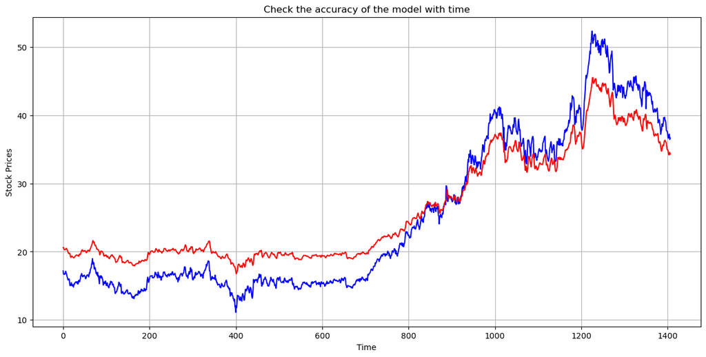

```python
# Ploting the graph of stock prices with time - Training Data
print("Red - Predicted Stock Prices  ,  Blue - Actual Stock Prices")
plt.rcParams["figure.figsize"] = (15,7)
plt.plot(trainY  , 'b')
plt.plot(train_pred, 'r')
plt.xlabel('Time')
plt.ylabel('Stock Prices')
plt.title('Check the accuracy of the model with time')
plt.grid(True)
plt.show()
```

```python
#Prediction Full Data

stocks_pred = model.predict(stocksX)
stocks_pred = scaler.inverse_transform(stocks_pred)
stocksY = stocksY.reshape(stocksY.shape[0] , 1)
stocksY = scaler.inverse_transform(stocksY)
print ('Display Accuracy Training Data')
display (r2_score(stocksY,stocks_pred))
```

```
Display Accuracy Training Data
```

```
0.907668493836231
```

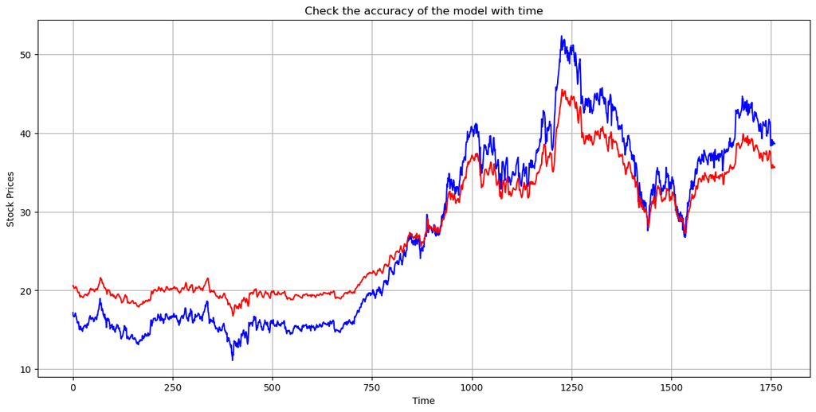

```python
#Plot the Graph
plt.rcParams["figure.figsize"] = (15,7)
plt.plot(stocksY  , 'b')
plt.plot(stocks_pred, 'r')
plt.xlabel('Time')
plt.ylabel('Stock Prices')
plt.title('Check the accuracy of the model with time')
plt.grid(True)
plt.show()
```

```python
#Concat original and prediction data
# Extract the data related to company - YHOO
results= df[df.symbol.isin (['YHOO'])]
# Update the data frame starting with 2nd records , since first prediction is for 2nd record
results= results [2:]
# Reset the index 0, 1,2 etc
results = results.reset_index(drop=True)
# Convert Predicted Value to Data Frame
df_stocks_pred= pd.DataFrame(stocks_pred, columns = ['Close_Prediction'])
# Concat Original and prediction data
results= pd.concat([results,df_stocks_pred],axis =1)
results.to_csv('results.csv')
display(results)
```

|  | date | symbol | open | close | low | high | volume | Close_Prediction |
| --- | --- | --- | --- | --- | --- | --- | --- | --- |
| 0 | 2010-01-06 | YHOO | 17.170000 | 17.170000 | 17.070000 | 17.299999 | 16422000.0 | 20.591488 |
| 1 | 2010-01-07 | YHOO | 16.809999 | 16.700001 | 16.570000 | 16.900000 | 31816300.0 | 20.611570 |
| 2 | 2010-01-08 | YHOO | 16.680000 | 16.700001 | 16.620001 | 16.760000 | 15470000.0 | 20.425705 |
| 3 | 2010-01-11 | YHOO | 16.770000 | 16.740000 | 16.480000 | 16.830000 | 16181900.0 | 20.276304 |
| 4 | 2010-01-12 | YHOO | 16.650000 | 16.680000 | 16.600000 | 16.860001 | 15672400.0 | 20.290478 |
| ... | ... | ... | ... | ... | ... | ... | ... | ... |
| 1755 | 2016-12-23 | YHOO | 38.459999 | 38.660000 | 38.369999 | 38.810001 | 3840100.0 | 35.744068 |
| 1756 | 2016-12-27 | YHOO | 38.590000 | 38.919998 | 38.500000 | 39.070000 | 4240300.0 | 35.582211 |
| 1757 | 2016-12-28 | YHOO | 39.119999 | 38.730000 | 38.709999 | 39.220001 | 4393500.0 | 35.736439 |
| 1758 | 2016-12-29 | YHOO | 38.759998 | 38.639999 | 38.480000 | 38.930000 | 4170200.0 | 35.753048 |
| 1759 | 2016-12-30 | YHOO | 38.720001 | 38.669998 | 38.430000 | 39.000000 | 6431600.0 | 35.653461 |

1760 rows × 8 columns

# similarly we can finD ADBE COMPANY PREDICTION just by replacing stocks with stocks1

# or simply arranging forloop for the different companies.(by using list in which element can be like [stocks1,stocks2 etc..,]of individual company